# Quasi-Poisson Regression for Biking counts on NYC bridges

Zackary Petrasek

11/8/2026

# 1 Introduction

In this assignment we build Poisson regression models for biking data from July 2017, to see whether we can describe the daily count of cyclists on the Brooklyn Bridge using the day of the week and the weather. This assignment adds a **quasi-Poisson** model, which is meant to handle the situation where the counts vary more than a regular Poisson model allows (overdispersion), and uses simplified weather predictors (`AvgTemp` and `NewPrecip`).

## 1.1 Description of the Data and Variables

The data come from the Traffic Information Management System and give the cyclist counts on the Queens, Manhattan, Williamsburg, and Brooklyn bridges for each day in July 2017. July has 31 days, so there are 31 observations. This report uses the count for the Brooklyn Bridge (`BrooklynBridge`) as the response. The original predictors are the day of the week (`Day`), the amount of precipitation (`Precipitation`), and the high and low temperatures for the day (`HighTemp` and `LowTemp`).

## 1.2 Reading and cleaning the data

The Excel file stored dates as serial numbers, so `Date` and `Day` did not come through correctly. I used `Date` to rebuild the day of the week and then dropped it, since it is only an observation ID. The seven days of the week were then collapsed into a single binary variable, `Day` (explained below). Following the assignment instructions, I replaced `HighTemp` and `LowTemp` with one variable, `AvgTemp = (HighTemp + LowTemp)/2`, and discretized `Precipitation` into `NewPrecip` (0 if there was no precipitation that day, 1 if there was any). I dropped `Total` because this report models only the Brooklyn Bridge count, not the share of all bridge traffic. Because the sample is small, with only 4 or 5 observations for each day of the week, I looked for a meaningful way to group `Day` to increase the sample size per level. I decided to group the `Day` into a 1 for a weekend day, including Friday as Friday is often considered the start of the weekend by many, and 0 for the other days.

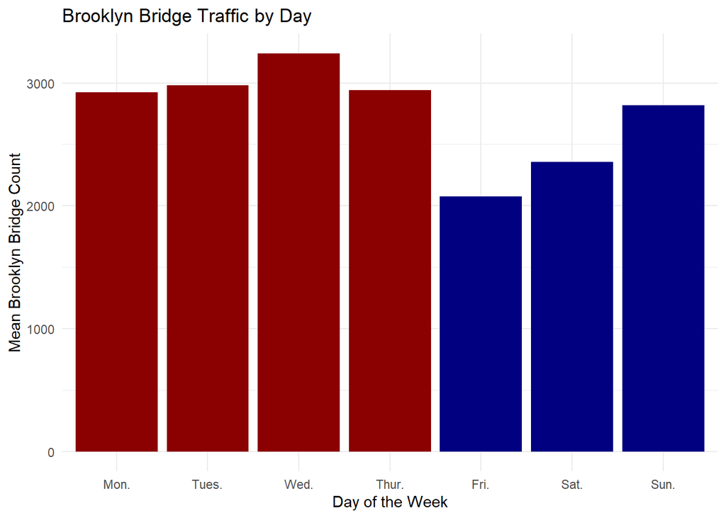

```r
# Create functions to be used throughout the file
# small helper: turn a log-scale coefficient into a signed percent change in the expected count
pct <- function(b) sprintf("%+.1f%%", 100 * (exp(b) - 1))
# plain-language version: "12% more" / "8% fewer"
chg <- function(b) sprintf("%.0f%% %s", abs(100 * (exp(b) - 1)), ifelse(b >= 0, "more", "fewer"))
# format p-values for tables and text: very small values are shown as "< 0.0001" instead of 0
pfmt <- function(p) ifelse(p < 0.0001, "< 0.0001", sprintf("%.4f", p))



#  Read sheet 'data4' (Brooklyn Bridge, July 2017) from the excel file provided in-class
dat <- read.xlsx("https://zackarypetrasek.github.io/STA321/homeworks/hw6/w09-AssignDataSet.xlsx",
                 sheet = "data4")

# Column names in this sheet have trailing spaces (e.g. "HighTemp "),
#    which read.xlsx turns into dots. Keep letters only: "HighTemp", "LowTemp", ...
names(dat) <- gsub("[^A-Za-z]", "", names(dat))

# Excel stores dates as serial numbers (42917 = July 1, 2017). Convert them back.
dat$Date <- as.Date(as.numeric(dat$Date), origin = "1899-12-30")

#  Rebuild Day from the real calendar date.
#    format(..., "%u") gives 1 = Monday ... 6 = Saturday, 7 = Sunday
dat$Day <- format(dat$Date, "%u")

# Keep only the variables used in the models.
biking <- data.frame(
  # Day is binary: 1 = Friday, Saturday or Sunday (5, 6, 7); 0 = Monday to Thursday (1-4)
  Day            = ifelse(dat$Day %in% c(5, 6, 7), 1, 0),
  NewPrecip      = ifelse(dat$Precipitation > 0, 1, 0),
  AvgTemp        = (as.numeric(dat$HighTemp) + as.numeric(dat$LowTemp)) / 2,
  BrooklynBridge = as.numeric(dat$BrooklynBridge)
)

# Clean data for the bar chart
plot_data <- dat %>%
  group_by(Day) %>%
  summarize(total_bridge = mean(BrooklynBridge, na.rm = TRUE)) %>%
  mutate(day_label = factor(Day, levels = c(1,2,3,4,5,6,7),
                            labels = c("Mon.","Tues.","Wed.","Thur.","Fri.","Sat.","Sun.")))

# Bar chart of the mean count for each day of the week
ggplot(plot_data, aes(x = day_label, y = total_bridge, fill=day_label)) +
  geom_col() +
  scale_fill_manual(values = c("Mon."= "darkred", "Tues."= "darkred", "Wed."= "darkred", "Thur." = "darkred", "Sun."= "navy", "Fri." = "navy", "Sat." = "navy")) +
  guides(fill="none")+
  labs(title = "Brooklyn Bridge Traffic by Day",
       x = "Day of the Week",
       y = "Mean Brooklyn Bridge Count") +
  theme_minimal()
```

Looking at the bar chart, we can clearly see that weekend days have fewer cyclists, on average, than weekdays. The mean count is 2441 cyclists on the Friday-to-Sunday days and 3015 on the Monday-to-Thursday days.

## 1.3 Variable definitions

The final list of variables used:

- `Day` (1 if Friday, Saturday or Sunday, 0 if Monday to Thursday)
- `NewPrecip` (0 if no precipitation, 1 if any precipitation)
- `AvgTemp` (average of the high and low temperature for the day, in degrees Fahrenheit)
- `BrooklynBridge` (number of cyclists crossing the Brooklyn Bridge that day; the response)

```r
# Gather objects for in line coding
n.fs    <- sum(biking$Day == 1)
n.other <- sum(biking$Day == 0)
p.fs    <- sum(biking$Day == 1 & biking$NewPrecip == 1)
p.other <- sum(biking$Day == 0 & biking$NewPrecip == 1)
most <- max(table(biking$Day, biking$NewPrecip))

# Quick look at the data: summary statistics and the cross-tabulation of the two indicator variables
kable(table(Day = biking$Day, NewPrecip = biking$NewPrecip),
      caption = "Number of days by Day (rows) and NewPrecip (columns)")
```

Number of days by Day (rows) and NewPrecip (columns)

|  | 0 | 1 |
| --- | --- | --- |
| 0 | 14 | 3 |
| 1 | 9 | 5 |

The two indicator variables overlap a bit: 5 of the 14 Friday/Saturday/Sunday days had precipitation, compared with 3 of the 17 Monday-to-Thursday days. The largest group is dry Monday-to-Thursday days (14 of 31 observations). The days with precipitation are the smallest groups (3 and 5 days), so estimates for them are less certain.

# 2 Research Questions

1. Is the **number** of cyclists on the Brooklyn Bridge related to the day type (Friday/Saturday/Sunday vs. Monday to Thursday), to whether there was precipitation, and to the average temperature? The response variable is `BrooklynBridge`.
2. Do the counts behave like a regular Poisson variable (variance equal to the mean)? If not, how do we adjust the model?
3. Which model (Poisson or quasi-Poisson) should be the final model, and which predictors does it keep?

# 3 Creating the model

In this section we will create our final model, interpret the coefficients in terms of the model, and create a visual tool to compare the impact of the different significant variables.

## 3.1 Poisson regression: assumptions and idea

The assumptions of a Poisson regression model are:

- The response is a **count** (of events per unit of time or space).
- Log linearity: the log of the mean count is a linear function of the predictors.
- Independence: the observations are independent.
- Equal mean and variance: a Poisson random variable has its variance equal to its mean, $Var(Y) = E(Y)$.

The **quasi-Poisson** model keeps the same mean structure (so it gives the same estimated coefficients) but relaxes the last assumption to $Var(Y) = \phi\, E(Y)$, where $\phi$ is the dispersion parameter. When $\phi > 1$ the data are overdispersed, and a regular Poisson model gives standard errors that are too small and p-values that are too small. The quasi-Poisson model multiplies the standard errors by $\sqrt{\hat\phi}$ to correct this.

## 3.2 The regular Poisson model

The first thing we will do is create the Poisson regression model based on counts, and then we will go over diagnostics to see if the model follows the assumptions for Poisson regression models.

```r
# Regular Poisson regression with the three predictors (log link)
pois.full <- glm(BrooklynBridge ~ Day + NewPrecip + AvgTemp,
                 family = poisson(link = "log"), data = biking)
pois.tab <- round(as.data.frame(summary(pois.full)$coef), 4)
pois.tab[["Pr(>|z|)"]] <- pfmt(summary(pois.full)$coef[, 4])
kable(pois.tab, caption = "Regular Poisson model for the Brooklyn Bridge counts")
```

Regular Poisson model for the Brooklyn Bridge counts

|  | Estimate | Std. Error | z value | Pr(>\|z\|) |
| --- | --- | --- | --- | --- |
| (Intercept) | 7.3440 | 0.0548 | 133.9533 | < 0.0001 |
| Day | -0.1444 | 0.0071 | -20.2865 | < 0.0001 |
| NewPrecip | -0.3693 | 0.0089 | -41.3852 | < 0.0001 |
| AvgTemp | 0.0094 | 0.0007 | 13.2758 | < 0.0001 |

In this model all the z-tests give very small p-values, which would suggest strong evidence for every predictor. This is only trustworthy if the Poisson assumption (variance = mean) holds.

## 3.3 Diagnostics and the estimated dispersion parameter

To check to make sure that the Poisson assumption holds we will look at the dispersion parameter, and run a Pearson chi-squared test to see if there is a dispersion issue in the model.

```r
# Pearson-based estimate of the dispersion parameter: sum of squared Pearson residuals / residual df
pearson.chisq <- sum(residuals(pois.full, type = "pearson")^2)
phi.hat       <- pearson.chisq / df.residual(pois.full)
dev.ratio     <- deviance(pois.full) / df.residual(pois.full)
p.disp        <- pchisq(pearson.chisq, df.residual(pois.full), lower.tail = FALSE)

disp.tab <- data.frame(
  Quantity = c("Estimated dispersion (Pearson chi-square / df)",
               "Residual deviance / df",
               "Residual df",
               "p-value for H0: no overdispersion (Pearson chi-square test)"),
  Value = c(sprintf("%.3f", phi.hat), sprintf("%.3f", dev.ratio),
            as.character(df.residual(pois.full)), pfmt(p.disp)))
kable(disp.tab, caption = "Dispersion diagnostics for the Poisson model")
```

Dispersion diagnostics for the Poisson model

| Quantity | Value |
| --- | --- |
| Estimated dispersion (Pearson chi-square / df) | 82.286 |
| Residual deviance / df | 85.751 |
| Residual df | 27 |
| p-value for H0: no overdispersion (Pearson chi-square test) | < 0.0001 |

The estimated dispersion parameter is $\hat\phi =$ 82.3. For a valid Poisson model this should be close to 1. Here it is 82.3 times larger, and the Pearson chi-square test for overdispersion gives a p-value of < 0.0001.

**Decision:** As the estimated dispersion is clearly larger than 1, based on both the dispersion estimate and the chi-square test, the counts are overdispersed and the regular Poisson model is not appropriate.

## 3.4 Quasi-Poisson model

As there is overdispersion the next step is to create a quasi-Poisson, which takes into account the overdispersion by inflating the variance by the dispersion parameter. This will make our new standard errors and p-values more accurate compared to the normal Poisson model.

```r
# Quasi-Poisson: same mean model, but the variance is phi * mean.
qp.full <- glm(BrooklynBridge ~ Day + NewPrecip + AvgTemp,
               family = quasipoisson(link = "log"), data = biking)
qp.tab <- round(as.data.frame(summary(qp.full)$coef), 4)
qp.tab[["Pr(>|t|)"]] <- pfmt(summary(qp.full)$coef[, 4])
kable(qp.tab, caption = "Quasi-Poisson model for the Brooklyn Bridge counts")
```

Quasi-Poisson model for the Brooklyn Bridge counts

|  | Estimate | Std. Error | t value | Pr(>\|t\|) |
| --- | --- | --- | --- | --- |
| (Intercept) | 7.3440 | 0.4973 | 14.7669 | < 0.0001 |
| Day | -0.1444 | 0.0646 | -2.2364 | 0.0338 |
| NewPrecip | -0.3693 | 0.0810 | -4.5623 | < 0.0001 |
| AvgTemp | 0.0094 | 0.0064 | 1.4635 | 0.1549 |

```r
# Gather objects for in-line coding
same.coef <- isTRUE(all.equal(coef(pois.full), coef(qp.full)))
phi.qp    <- summary(qp.full)$dispersion
sq        <- summary(qp.full)$coef

# Side-by-side comparison of the two fits
comp <- data.frame(
  `Estimate (both)`      = coef(pois.full),
  `SE (Poisson)`         = summary(pois.full)$coef[, "Std. Error"],
  `SE (quasi-Poisson)`   = summary(qp.full)$coef[, "Std. Error"],
  `p-value (Poisson)`    = pfmt(summary(pois.full)$coef[, "Pr(>|z|)"]),
  `p-value (quasi-Poisson)` = pfmt(summary(qp.full)$coef[, "Pr(>|t|)"]),
  check.names = FALSE)
kable(comp, digits = 4, caption = "Poisson vs. quasi-Poisson: same estimates, different standard errors and p-values")
```

Poisson vs. quasi-Poisson: same estimates, different standard errors and p-values

|  | Estimate (both) | SE (Poisson) | SE (quasi-Poisson) | p-value (Poisson) | p-value (quasi-Poisson) |
| --- | --- | --- | --- | --- | --- |
| (Intercept) | 7.3440 | 0.0548 | 0.4973 | < 0.0001 | < 0.0001 |
| Day | -0.1444 | 0.0071 | 0.0646 | < 0.0001 | 0.0338 |
| NewPrecip | -0.3693 | 0.0089 | 0.0810 | < 0.0001 | < 0.0001 |
| AvgTemp | 0.0094 | 0.0007 | 0.0064 | < 0.0001 | 0.1549 |

As expected, the two models have the same estimated coefficients, and the dispersion reported by the quasi-Poisson fit is 82.3. The quasi-Poisson standard errors are larger than the Poisson ones by the factor $\sqrt{\hat\phi} \approx$ 9.07, and the p-values move up accordingly. At the 5% level the quasi-Poisson model finds `Day` and `NewPrecip` significant with p-values of 0.0338 and < 0.0001 respectively. However, at an alpha level of 0.05 `AvgTemp` was not found to be statistically significant, with a p-value of 0.1549.

## 3.5 Final Quasi-Poisson model

As `AvgTemp` was not significant we will drop it from our final model and check our new variables to make sure they remain significant in the new model.

```r
# Quasi-Poisson: dropping AvgTemp.
qp.final <- glm(BrooklynBridge ~ Day + NewPrecip,
               family = quasipoisson(link = "log"), data = biking)

# Gather objects to make in-line coding easier
sq        <- summary(qp.final)$coef
phi.final <- summary(qp.final)$dispersion

# Side-by-side comparison of the two fits
comp <- data.frame(
  Estimate            = coef(qp.final),
  `SE (quasi-Poisson)` = summary(qp.final)$coef[, "Std. Error"],
  `p-value`           = pfmt(summary(qp.final)$coef[, "Pr(>|t|)"]),
  check.names = FALSE)
kable(comp, digits = 4, caption = "Final model with standard errors and p-values")
```

Final model with standard errors and p-values

|  | Estimate | SE (quasi-Poisson) | p-value |
| --- | --- | --- | --- |
| (Intercept) | 8.0683 | 0.0418 | < 0.0001 |
| Day | -0.1497 | 0.0651 | 0.0292 |
| NewPrecip | -0.3752 | 0.0817 | < 0.0001 |

At the 5% level the quasi-Poisson model finds `Day` and `NewPrecip` significant with p-values of 0.0292 and < 0.0001 respectively. This means we do not need to drop any more variables and can use this model as our final model for interpretation and visualization. The final model has a dispersion of 84.

### 3.5.1 Interpretation of the coefficients

```r
# exp(coefficient) = multiplicative change in the EXPECTED daily count.
# 95% intervals use the t distribution because the dispersion is estimated.
b   <- coef(qp.final)
se  <- summary(qp.final)$coef[, "Std. Error"]
tc  <- qt(0.975, df.residual(qp.final))
est <- cbind(Estimate = b, Lower95 = b - tc * se, Upper95 = b + tc * se)
kable(round(exp(est), 3), caption = "Multiplicative effects on the expected daily count (quasi-Poisson, 95% CI)")
```

Multiplicative effects on the expected daily count (quasi-Poisson, 95% CI)

|  | Estimate | Lower95 | Upper95 |
| --- | --- | --- | --- |
| (Intercept) | 3191.697 | 2929.740 | 3477.076 |
| Day | 0.861 | 0.753 | 0.984 |
| NewPrecip | 0.687 | 0.581 | 0.812 |

With the other predictors held fixed:

- **`Day`:** the expected count on a Friday, Saturday or Sunday is 0.861 times the expected count on a Monday-to-Thursday day (-13.9%; 95% CI for the ratio: 0.753 to 0.984).
- **`NewPrecip`:** on a day with precipitation the expected count is 0.687 times that of a dry day (-31.3%; 95% CI: 0.581 to 0.812).
- The `Day` effect is weaker than the precipitation effect: its p-value is 0.0292 and its interval comes close to 1. The grouping of days was also chosen after looking at the data, so this effect should be read with some caution.
- **Intercept:** the expected count on a dry Monday-to-Thursday day is $e^{8.068} \approx$ 3192 cyclists.

## 3.6 Visualizing the relationship

The final model has two predictors, so it predicts four kinds of days: dry or precipitation days, each on a Monday-to-Thursday or a Friday/Saturday/Sunday. The plot below shows the observed daily counts (dots) for each of these groups together with the quasi-Poisson expected count (diamond) and its 95% confidence interval. Groups with no observed days are not shown, and `n` is the number of days in each group.

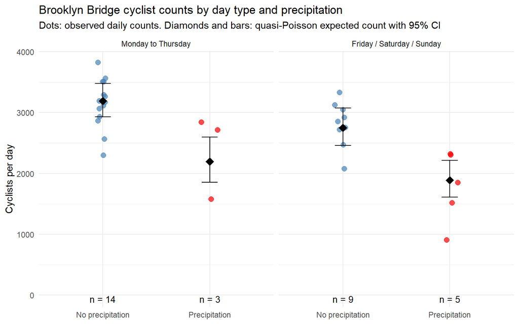

```r
# Label the groups for the plot
lab <- function(d) {
  d$DayType <- factor(d$Day, levels = c(0, 1), labels = c("Monday to Thursday", "Friday / Saturday / Sunday"))
  d$Weather <- factor(d$NewPrecip, levels = c(0, 1), labels = c("No precipitation", "Precipitation"))
  d
}
obs.df <- lab(biking)

# Expected count for each of the 4 combinations from the FINAL model (no AvgTemp),
# on the log scale with standard errors (se.fit already includes the dispersion), then back-transformed.
grid <- lab(expand.grid(Day = c(0, 1), NewPrecip = c(0, 1)))
pr <- predict(qp.final, newdata = grid, type = "link", se.fit = TRUE)
grid$fit   <- exp(pr$fit)
grid$lower <- exp(pr$fit - tc * pr$se.fit)
grid$upper <- exp(pr$fit + tc * pr$se.fit)

# number of observed days in each group; combinations with no days are dropped
n.tab <- biking %>% count(Day, NewPrecip, name = "n")
grid  <- merge(grid, n.tab, by = c("Day", "NewPrecip"))

# Create object for in-line coding
base <- exp(b["(Intercept)"])

ggplot() +
  geom_jitter(data = obs.df, aes(Weather, BrooklynBridge, color = Weather),
              width = 0.08, height = 0, size = 2.5, alpha = 0.7) +
  geom_errorbar(data = grid, aes(Weather, ymin = lower, ymax = upper), width = 0.15) +
  geom_point(data = grid, aes(Weather, fit), shape = 18, size = 4) +
  geom_text(data = grid, aes(Weather, y = -Inf, label = paste0("n = ", n)), vjust = -0.6, size = 3.5) +
  facet_wrap(~ DayType) +
  scale_color_manual(values = c("No precipitation" = "steelblue", "Precipitation" = "red")) +
  expand_limits(y = 0) +
  labs(title = "Brooklyn Bridge cyclist counts by day type and precipitation",
       subtitle = "Dots: observed daily counts. Diamonds and bars: quasi-Poisson expected count with 95% CI",
       x = NULL, y = "Cyclists per day") +
  theme_minimal() +
  theme(legend.position = "none")
```

Under the final model the expected count on a dry Monday-to-Thursday day is about 3192 cyclists. A Friday/Saturday/Sunday changes this by -13.9% and precipitation by -31.3%. Because the model has no interaction, these two effects simply multiply: for example a Friday/Saturday/Sunday with precipitation is expected to have about 1888 cyclists. Groups with only a few days (see `n` in the plot) have wide intervals and should be read with caution.

Since `AvgTemp` was dropped from the model, the plot below shows the counts against `AvgTemp` to illustrate why. The line is a separate quasi-Poisson fit of the count on `AvgTemp` alone for each day type, shown for reference only.

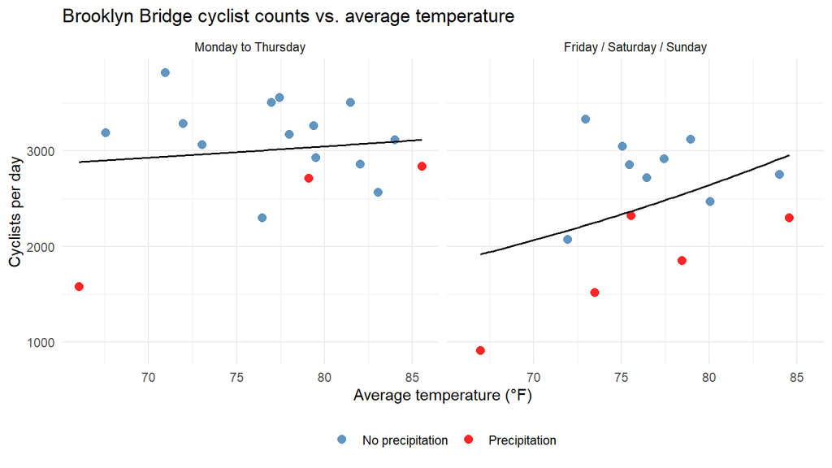

```r
# Counts vs. temperature, colored by precipitation, one panel per day type.
# The black line is a one-predictor quasi-Poisson trend on AvgTemp alone (reference only).
ggplot(obs.df, aes(AvgTemp, BrooklynBridge)) +
  geom_point(aes(color = Weather), size = 2.5, alpha = 0.85) +
  geom_smooth(aes(group = 1), method = "glm", method.args = list(family = quasipoisson),
              se = FALSE, color = "black", linewidth = 0.7) +
  facet_wrap(~ DayType) +
  scale_color_manual(values = c("No precipitation" = "steelblue", "Precipitation" = "red")) +
  labs(title = "Brooklyn Bridge cyclist counts vs. average temperature",
       x = "Average temperature (°F)", y = "Cyclists per day") +
  theme_minimal() +
  theme(legend.position = "bottom", legend.title = element_blank())
```

```r
# Mean temperature on precipitation vs. dry days, for in-line coding
temp.p <- mean(biking$AvgTemp[biking$NewPrecip == 1])
temp.d <- mean(biking$AvgTemp[biking$NewPrecip == 0])
```

The plot shows an upward trend in the counts as `AvgTemp` increases, but the lowest counts are mostly red precipitation days. Precipitation days averaged 76.2°F, compared with 77.1°F for dry days, so part of the apparent temperature pattern may really be a precipitation effect. This would explain why `AvgTemp` adds little once `NewPrecip` is in the model.

# 4 Conclusions, Limitations and Recommendations

**Conclusions.**

- The regular Poisson model is not appropriate for these data: the estimated dispersion is 82.3 instead of about 1. The quasi-Poisson model, which has the same coefficients but honest standard errors, is the better final model.
- After this correction, Friday/Saturday/Sunday have about 14% fewer cyclists than Monday-to-Thursday days, and days with precipitation have about 31% fewer cyclists than dry days. The Day effect is the weaker of the two. Average temperature was not significant and was dropped from the final model.

**Limitations.**

- There are only 31 days from a single month, so the results describe July 2017 and should not be generalized to other months or years.
- Grouping the days into Friday/Saturday/Sunday vs. Monday to Thursday (a grouping chosen after looking at the data), and precipitation into yes/no, loses information (for example, light vs. heavy rain).
- Consecutive days are not truly independent (weather and events carry over from day to day), which Poisson-family models assume. This violation is another possible reason for the extra variation, and the quasi-Poisson correction does not fix it.
- Quasi-Poisson models have no likelihood, so AIC and likelihood-ratio tests are not available for comparing models.

**Recommendations and possible improvements.**

- A negative binomial regression is a natural alternative for overdispersed counts and would allow likelihood-based comparison.
- With more months of data we could use the actual day of the week and the amount of precipitation, add interaction terms (for example, weekend and temperature), and reduce the dependence between days.
- For planning (for example staffing, maintenance, or bike-lane decisions), the most useful use of the model is the expected count for a given day type and weather (dry or precipitation), together with the uncertainty bands shown in the plot.

# 5 Summary of Findings

We looked at how many cyclists crossed the Brooklyn Bridge each day in July 2017 and how that number relates to the day of the week, whether it rained, and the temperature. Our first model assumed daily counts would be fairly steady from day to day. They weren’t. They varied far more than that assumption allows, which made our first results look more certain than they should. As a result, we switched to a model that allows for this extra variation. It gives the same estimates but more honest measures of uncertainty.

The adjusted model suggests that a Friday, Saturday or Sunday has about 14% fewer cyclists than a Monday-to-Thursday day, and a day with precipitation has about 31% fewer cyclists than a dry day. Once these two were accounted for, the average temperature did not show a clear effect, so we left it out. Because this is only one month of data, these results describe July 2017 and should be treated as a starting point rather than firm rules to apply broadly.